# Practical: ordination with other packages

Summer school in model-based multivariate analysis

Bert van der Veen

# Background

On this last day of the workshop, I will demonstrate the use of a few other R packages for applying GLLVMs to fit JSDMs or model-based ordination. Most of these are slower in fitting than the `gllvm` R-package, or provide considerably fewer tools. However, that is not to say they are not useful: there are things that are currently difficult to do in the `gllvm` package that are easier to implement with these other R-packages. Either way, this provides you with some reference material on what `gllvm` does so well!

We will briefly look at some of the R-packages that were also in my presentation. This includes:

- `mvabund`
- `boral`
- `Hmsc`
- `ecoCopula`
- `glmmTMB`
- `gmf`
- `RCM`
- `CBFM`
- `VGAM`

I will take a (very) small dataset, because it might otherwise take too long to try some of these packages, and because we need something that all packages can work with. The (reduced) spider data is included in the `mvabund` package, and it contains observations of 12 species at 28 sites. There is an extended version of the dataset in `gllvm` available that contains 100 sites, but the environmental covariates were only observed at these 28.

```r
data(spider, package = "mvabund")
Y <- spider$abund;row.names(Y) <- 1:nrow(Y)
X <- scale(spider$x)
```

## mvabund

The `mvabund` package was one of the first for analysing community ecological data. It fits vector GLMs (and a few other models), but its most important functionality is the `anova` function. It performs hypothesis testing based on resampling (so tends to be a little slow, even for small datasets), that can post-hoc account for correlations between species, even though the fitted models do not account for it.

```r
model <- mvabund::manyglm(Y~soil.dry+bare.sand+fallen.leaves+moss+herb.layer+reflection, data=data.frame(X))
anova(model)
```

```
## Time elapsed: 0 hr 1 min 8 sec
```

```
## Analysis of Deviance Table
##
## Model: Y ~ soil.dry + bare.sand + fallen.leaves + moss + herb.layer + reflection
##
## Multivariate test:
##               Res.Df Df.diff    Dev Pr(>Dev)
## (Intercept)       27
## soil.dry          26       1 147.30    0.001 ***
## bare.sand         25       1  26.89    0.123
## fallen.leaves     24       1 132.23    0.001 ***
## moss              23       1  29.70    0.077 .
## herb.layer        22       1  82.26    0.001 ***
## reflection        21       1  46.88    0.034 *
## ---
## Signif. codes:  0 '***' 0.001 '**' 0.01 '*' 0.05 '.' 0.1 ' ' 1
## Arguments:
##  Test statistics calculated assuming uncorrelated response (for faster computation)
##  P-value calculated using 999 iterations via PIT-trap resampling.
```

## boral

The `boral` package with main function `boral` fits GLLVMs using JAGS; i.e., it is based on the Bayesian statistics paradigm and fits with MCMC. MCMC is generally (very) slow, so model fitting can take a while:

```r
library(boral)
model1 <- boral::boral(Y, X, formula.X = ~ soil.dry + moss + fallen.leaves, lv.control=list(num.lv = 2), family = "poisson", save.model = TRUE)
```

As in the packages with numerical optimisation, we need to be careful when it comes to convergence with MCMC. The main difference, is that with MCMC we need to inspect convergence of each parameter visually:

```r
coda::traceplot(boral::get.mcmcsamples(model1))
```

[output not shown]

```r
model1$geweke.diag
```

```
## $geweke.diag
## $geweke.diag$lv.coefs
##               beta0
## Alopacce -0.6296173
## Alopcune  0.7007298
## Alopfabr -1.6311093
## Arctlute  1.4266946
## Arctperi  0.7786200
## Auloalbi  0.5911576
## Pardlugu  0.3474044
## Pardmont  0.4613911
## Pardnigr  1.2905438
## Pardpull  1.0603090
## Trocterr  0.3968110
## Zoraspin  1.5069156
##
## $geweke.diag$X.coefs
##            soil.dry       moss fallen.leaves
## Alopacce -0.5283320 -0.6455535    -0.9445372
## Alopcune  0.1802158 -1.7180438    -1.3707184
## Alopfabr -0.8582223 -2.6459483    -1.2595297
## Arctlute  0.6848157  0.1032888     0.1496787
## Arctperi  0.4455789 -0.6265130    -0.6066195
## Auloalbi  1.5371954  0.2630717    -0.8476893
## Pardlugu -0.9871957 -1.5405449    -0.9462141
## Pardmont -0.2663302 -1.5528218    -0.5898732
## Pardnigr  0.9794781 -0.2455449    -1.4429913
## Pardpull  0.6745331 -0.3603780    -0.7644879
## Trocterr  0.8295041 -0.2617530    -1.1879183
## Zoraspin  0.8701509  0.6812478    -1.0872298
##
##
## $prop.exceed
##
##      FALSE       TRUE
## 0.97916667 0.02083333
```

When the model has converged, we can inspect some of the results:

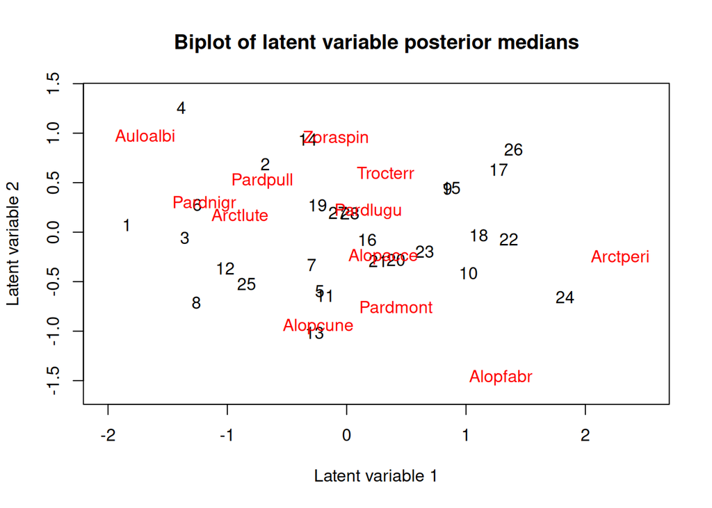

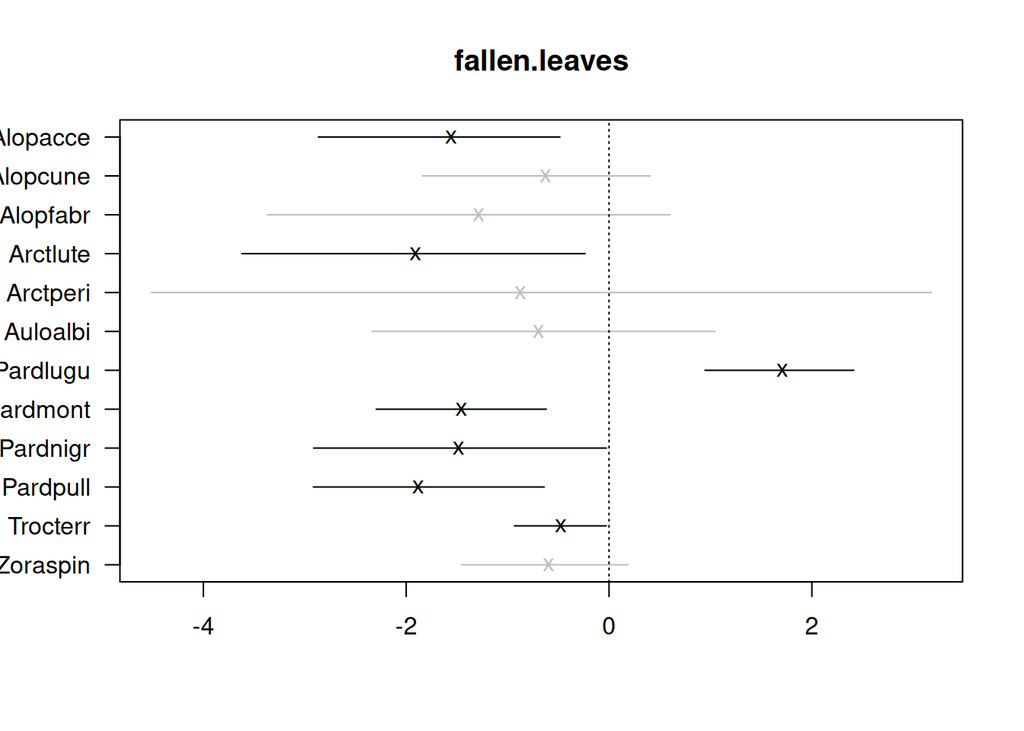

```
## $varpart.X
##  Alopacce  Alopcune  Alopfabr  Arctlute  Arctperi  Auloalbi  Pardlugu  Pardmont
## 0.7949580 0.2628324 0.6777761 0.6272666 0.7114958 0.4200706 0.6691312 0.5939233
##  Pardnigr  Pardpull  Trocterr  Zoraspin
## 0.4780458 0.5107102 0.6164724 0.6432554
##
## $varpart.lv
##  Alopacce  Alopcune  Alopfabr  Arctlute  Arctperi  Auloalbi  Pardlugu  Pardmont
## 0.2050420 0.7371676 0.3222239 0.3727334 0.2885042 0.5799294 0.3308688 0.4060767
##  Pardnigr  Pardpull  Trocterr  Zoraspin
## 0.5219542 0.4892898 0.3835276 0.3567446
##
## $varpart.row
## NULL
##
## $varpart.ranef
## NULL
```

## Hierarchical modeling of species communities (HMSC)

HMSC is currently the most popular package for fitting Joint Species Distribution Models in the Bayesian paradigm - it focuses on fitting models to presence-absence data but there are a few count distributions supported too. Here is code for fitting a basic GLLVM:

```r
library(Hmsc)
# need to set-up LVs
studyDesign = data.frame(sample=as.factor(1:nrow(Y)))
rL <- Hmsc::HmscRandomLevel(units = studyDesign$sample)
model2 <- Hmsc::Hmsc(Y, XFormula = ~fallen.leaves+soil.dry, XData= data.frame(X),
distr = "lognormal poisson", studyDesign = studyDesign,
ranLevels = list(sample = rL))
# Run mcmc
run =  Hmsc::sampleMcmc(model2, samples = 1000, nChains = 3,
              transient = 2500, verbose = 0)
```

```
## Computing chain 1
## Computing chain 2
## Computing chain 3
```

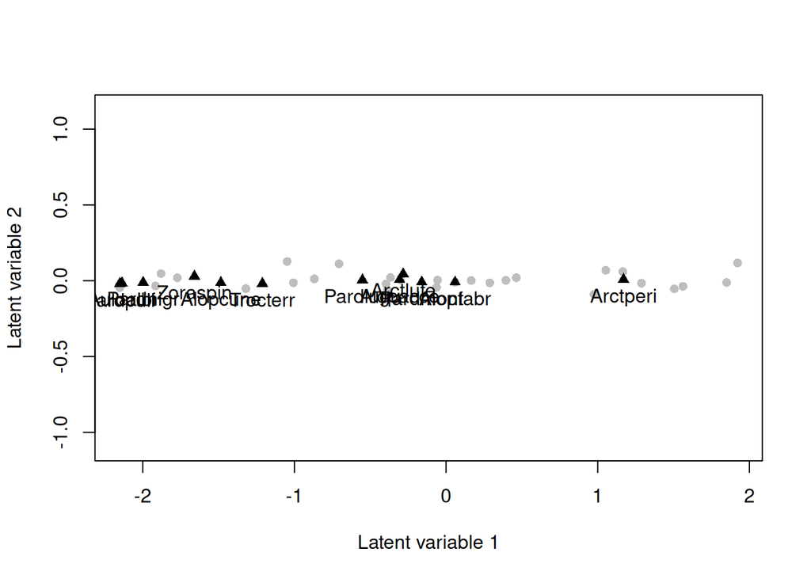

```r
# make biplot
etaPost=Hmsc::getPostEstimate(run, "Eta")
lambdaPost=Hmsc::getPostEstimate(run, "Lambda")
Hmsc::biPlot(run, etaPost = etaPost, lambdaPost = lambdaPost, factors = c(1,2))
```

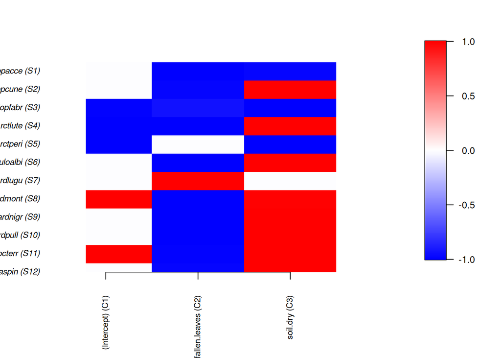

```r
betaPost=Hmsc::getPostEstimate(run, "Beta")
plotBeta(model2, post = betaPost) # heatmap of covariate coefficients
```

Note that there is much more that Hmsc can do than I have shown here: you can fit fourth-corner models, with Phylogenetic random effects as well, add additional random effects, specify the plot/sample level at which the latent variables are estimated, and incorporate spatial/temporal autocorrelation in the models. The package has a good set of vignettes that can help you figure out how to specify models.

Variance partitioning can be done with the following code.

```r
VP = computeVariancePartitioning(run)
par(mar=c(4,4,4,4))
plotVariancePartitioning(model2, VP = VP,
                         las = 2, horiz=F)
```

[output not shown]

`gllvm` has a similar VP function.

## ecoCopula

The ecoCopula package is presently quite limited in its functionality, but it can fit unconstrained ordinations -very- rapidly.

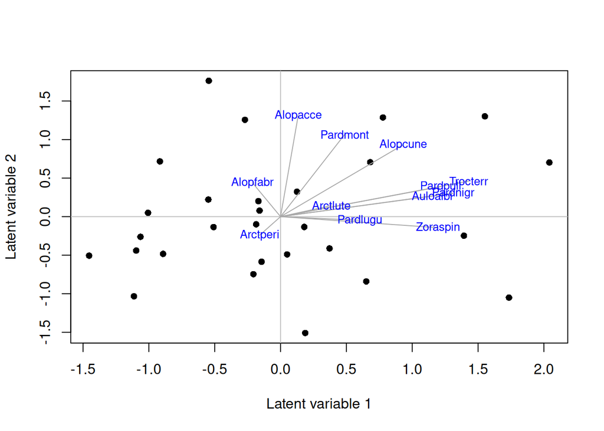

```r
library(ecoCopula)
preModel <- stackedsdm(Y, formula_X =~fallen.leaves+moss+soil.dry, data = X)
model3 <- cord(preModel)
plot(model3, biplot=TRUE)
```

## glmmTMB

This one we have also briefly covered on the first day: `glmmTMB` can be used for unconstrained ordination with random effects, and of course for general fitting of models with random effects and zero-inflated components. It does not have (much) functionality for presenting results, but there is support for a few additional R-packages that can help with that.

We need this code from [the glmmTMB github](https://github.com/glmmTMB/glmmTMB/issues/1012) to extract site and species scores:

```r
extract_rr <- function(object){
  listname <- "cond"
  cnms <- object$modelInfo$reTrms[[listname]]$cnms   ## list of (named) terms and X columns
  flist <- object$modelInfo$reTrms[[listname]]$flist ## list of grouping variables
  flist_asgn <- attr(flist, "assign")
  levs <- lapply(seq_along(flist_asgn), function(i) levels(flist[[flist_asgn[i]]]))

  reStruc <- object$modelInfo$reStruc[[paste0(listname, "ReStruc")]] ## random-effects structure
  nc <- vapply(reStruc, function(x) x$blockSize, numeric(1)) ## number of RE params per block
  pl <- object$obj$env$parList(object$fit$par, object$fit$parfull)

  #function to split b by the random effect terms
  split.bseq <- function(object){
    listname <- "cond"
    reStruc <- object$modelInfo$reStruc[[paste0(listname, "ReStruc")]] ## random-effects structure
    nc <- vapply(reStruc, function(x) x$blockSize, numeric(1)) ## number of RE params per block
    nb <- vapply(reStruc, function(x) x$blockReps, numeric(1)) ## number of blocks per RE (may != nlevs in some cases)
    ### splitting the b's into their respective random effects
    nbseq <- rep.int(seq_along(nb), nb * nc)       ## splitting vector
    return(nbseq)
  }
  nbseq <- split.bseq(object)      ## splitting vector
  ml.b <- split(pl$b, nbseq)
  ml <- ml.b

  for (i in seq_along(ml.b)) {
    ml[[i]] <- matrix(ml.b[[i]], ncol = nc[i], byrow = TRUE,
                      dimnames = list(levs[[i]], cnms[[i]]))
  }

  get_rank <- function(x){
    if(x[["blockCode"]]==9){
      p <- x$blockSize
      nt <- x$blockNumTheta
      rank <- (2*p + 1 - sqrt((2*p+1)^2 - 8*nt))/2
    } else
      rank <- 0
    return(rank)
  }

  rank <- vapply(object$modelInfo$reStruc$condReStruc,
                 get_rank,
                 FUN.VALUE=numeric(1))
  nlv <- rank[rank > 0]
  rrName <- names(nlv)
  rrBlock <- which(rank > 0)
  b = ml[[rrBlock]][,1:nlv]
  colnames(b) <- paste0("lv", 1:nlv)
  fact_load <- object$obj$env$report(object$fit$parfull)$fact_load[[rrBlock]]
  rownames(fact_load) <- cnms[[rrBlock]]

  return(list(fl = fact_load, b = b))
}
```

We need to format our data into long format as shown in [the glmmTMB vignette](https://cran.r-project.org/web/packages/glmmTMB/vignettes/covstruct.html#general-latent-variable-model):

```r
## organize data into long format
sppTot <- sort(colSums(spider$abund), decreasing = TRUE)
tmp <- cbind(spider$abund, spider$x)
tmp$id <- 1:nrow(tmp)
spiderDat <- reshape(tmp,
                     idvar = "id",
                     timevar = "Species",
                     times =  colnames(spider$abund),
                     varying = list(colnames(spider$abund)),
                     v.names = "abund",
                     direction = "long")
```

Then we can construct an unconstrained ordination:

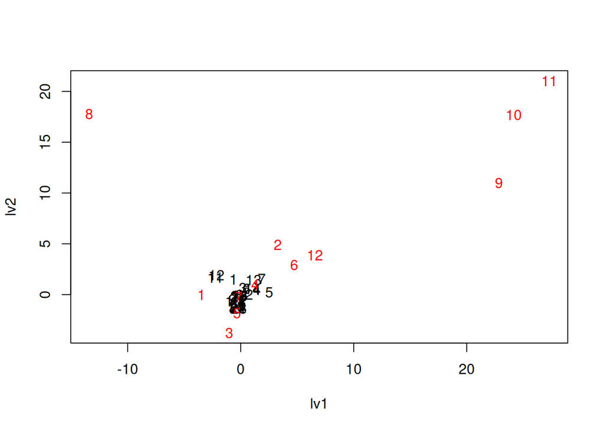

```r
library(glmmTMB)
model7 <- glmmTMB(abund ~ Species + Species:fallen.leaves + rr(Species + 0|id, d = 2),
                                             data = spiderDat)
rrstuf <- extract_rr(model7)
plot(rbind(rrstuf$b,rrstuf$fl), type = "n");
text(rrstuf$b);text(rrstuf$fl, col = "red")
```

## Generalized Matrix Factorization

The `gmf` package is not actively maintained, and it is also not on CRAN. It provides a different method for fitting unconstrained ordination GLLVMs, that is fast but can be very unstable.

```r
library(gmf)
# devtools::install_github("kidzik/gmf") # install with this code if you want to try
model8 <- gmf::gmf(Y, family = poisson(), p = 2)
```

```
## iteration 10, PQL = 0.02014865
## [1] "Stopped after 10 iterations with deviance 0.0201486498349967"
```

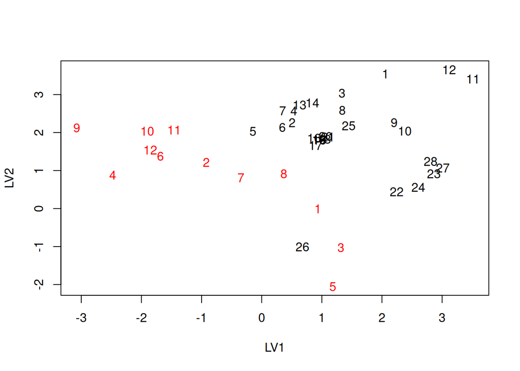

```r
plot(rbind(model8$u,model8$v), type = "n", xlab="LV1", ylab="LV2")
text(model8$u)
text(model8$v, col="red")
```

## RCM

The RCM package is geared towards analysis of (I think) microbial communities. It has some statistical issues also outlined in the associated article, and it (presently) only supports the negative-binomial distribution. In that case, you can use it to do unconstrained, constrained, and constrained additive ordination based on a fixed effects formulation. It requires the data to be formatted as a “phyloseq” object for constrained ordination.

Unconstrained ordination:

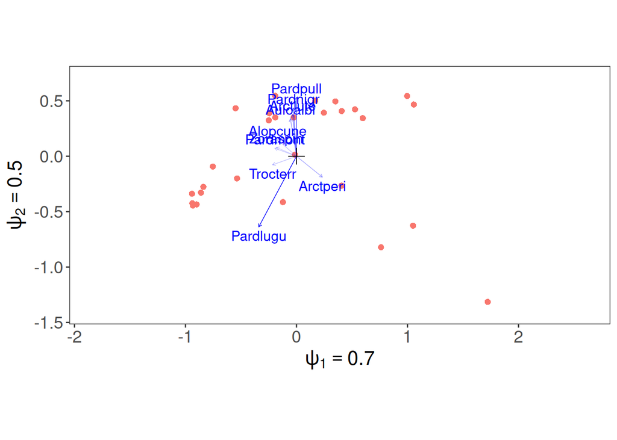

```r
# devtools::install_github("CenterForStatistics-UGent/RCM")
library(RCM)
library(phyloseq)
model9 <- RCM::RCM(Y, k = 2)
plot(model9)
```

Constrained ordination:

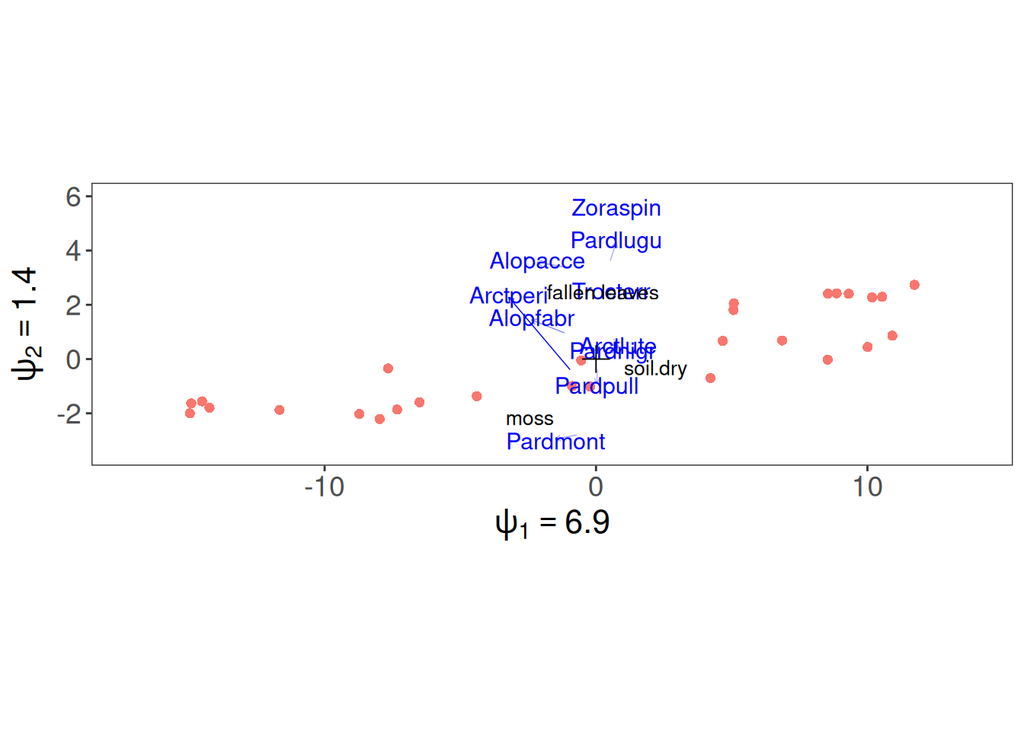

```r
library(phyloseq)
model10 <- RCM(phyloseq(otu_table(spider$abund, taxa_are_rows = FALSE), sample_data(spider$x)), covariates = c("soil.dry", "moss", "fallen.leaves"), k = 2)
plot(model10)
```

## Vector Generalized and Additive Models

I did not put this package on the list of packages to install, so please use `install.packages("VGAM")` if you want to try this out.

The VGAM package can be used for all kinds of analyses, but for multivariate analysis in particular it can be used for unconstrained, constrained, and doubly constrained ordinations, with or without unimodal response model (e.g., as in the `cqo` function. The implementation is even more unstable than in `gllvm`.), and for vector GLMs as in `mvabund`.

The following code implements an unconstrained ordination:

[output not shown]

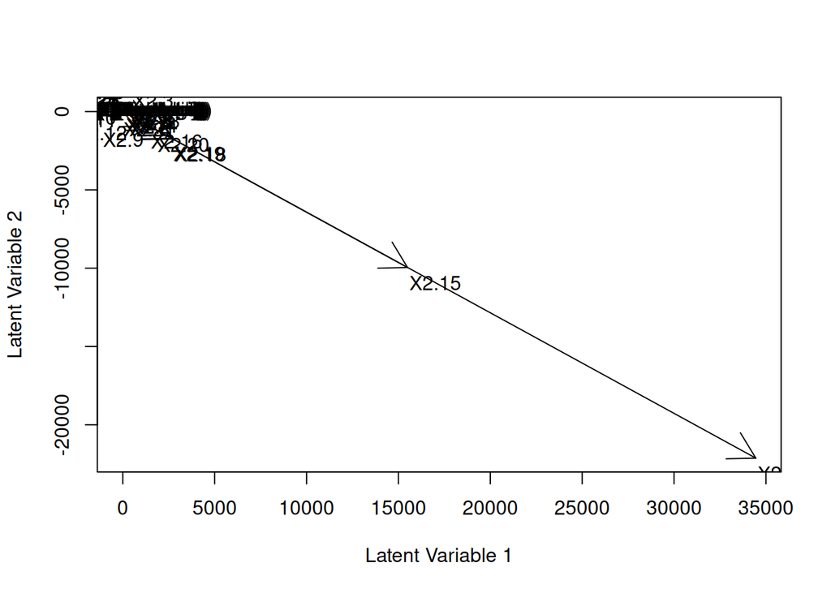

```r
library(VGAM)
# unconstrained (fixed effects) ordination
model4 <- rcim(Y, Rank = 2, family = poissonff)
lvplot(model4) # this plotting function is an acquired taste
```

A constrained ordination:

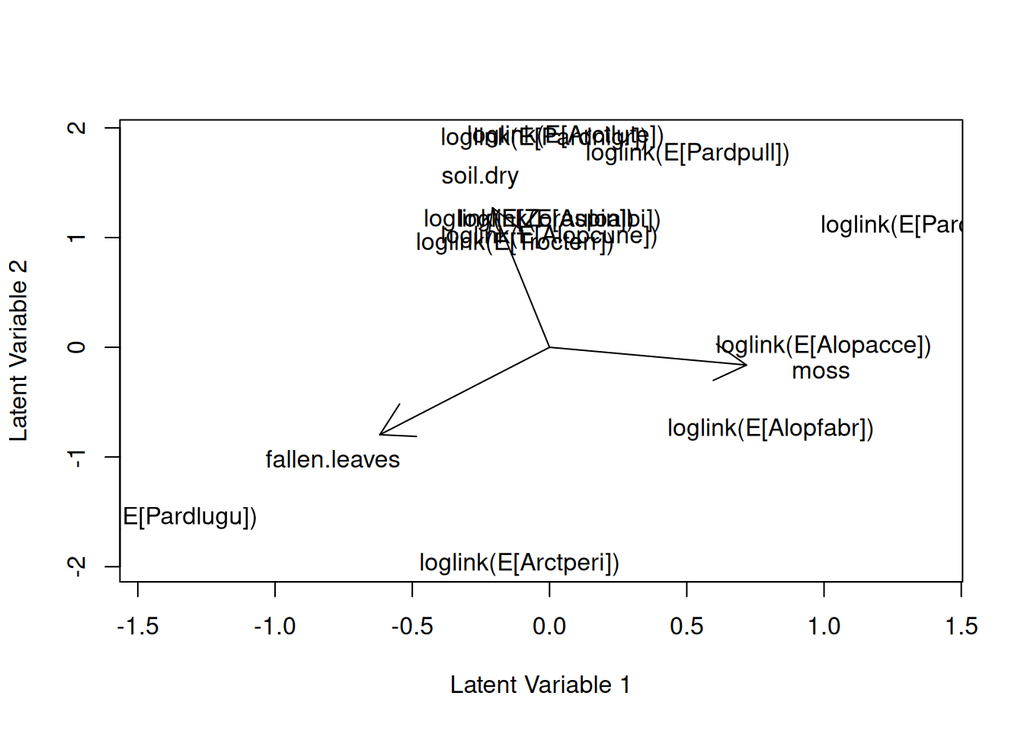

```r
# constrained (fixed effects) ordination
model5 <- rrvglm(Y ~ soil.dry+fallen.leaves+moss, data=data.frame(X), Rank = 2, family = poissonff)
lvplot(model5) # this plotting function is an acquired taste
```

A vector GLM:

```r
model6 <- vglm(Y ~ soil.dry+fallen.leaves+moss, data=data.frame(X), family = poissonff)
```

The VGAM package has so much functionality (but no random effects), it could use its own workshop.